# 大學停看聽 對於大學科系的分析

呂羿賢

2018年8月7日

一.良好問題定義  
任務:想了解大學科系與學類的延畢率 起薪等等，了解各科系的生態與潛力  
經驗數據:從政府開放式平台獲取的大學延畢率與各學類的畢業後三年平均薪水  
衡量方法:以公私立與學群劃分對照延畢率與就業薪水，做直接數據上的比較  
二:開始製作EDA  
1.匯入模組與資料

```r
library(readxl)
```

```r
library(ggplot2)
library(data.table)
s<-data.frame(fread('Student_RPT_19.csv'))
h<-read_excel("高教資料總表串聯3.xlsx")
```

2.數據圖  
先從比例去理解 延畢率由大至小與由小至大選出各別前二十位的大學與學類

```r
colnames(h)#釐清欄位總類別
```

```
##  [1] "學校類型"
##  [2] "private_public"
##  [3] "school"
##  [4] "department"
##  [5] "shool_and_department"
##  [6] "大考中心學群編號"
##  [7] "學群"
##  [8] "大考中心學類編號"
##  [9] "學類編號編碼"
## [10] "學校代碼"
## [11] "學校名稱"
## [12] "科系代碼之最後一筆"
## [13] "科系名稱之第一筆"
## [14] "校系代碼之第一筆"
## [15] "校系名稱之第一筆"
```

[output cut: 72 more lines]

```r
htl<-order(h$delay_rate,decreasing=T)#延畢率由小至大
lth<-order(h$delay_rate)#延畢率由大至小
lths<-head(h$shool_and_department[lth],20)#校系準時畢業前20
lthss<-head(h$school[lth],20)#學校準時畢業前20
lthsss<-table(lthss)#計算種類下數量
htls<-head(h$shool_and_department[htl],20)
htlss<-head(h$school[htl],20)
htlsss<-table(htlss)
lblslh <- paste(names(lthsss), lthsss, sep="")
print(lthsss)
```

```
## lthss
##     國立中山大學     國立中央大學     國立中正大學     國立中興大學
##                1                3                3                1
##     國立交通大學     國立成功大學     國立東華大學     國立屏東大學
##                3                1                3                2
##     國立政治大學 國立高雄師範大學
##                2                1
```

```r
print(names(lthsss))
```

```
##  [1] "國立中山大學"     "國立中央大學"     "國立中正大學"
##  [4] "國立中興大學"     "國立交通大學"     "國立成功大學"
##  [7] "國立東華大學"     "國立屏東大學"     "國立政治大學"
## [10] "國立高雄師範大學"
```

```r
print(lblslh)
```

```
##  [1] "國立中山大學1"     "國立中央大學3"     "國立中正大學3"
##  [4] "國立中興大學1"     "國立交通大學3"     "國立成功大學1"
##  [7] "國立東華大學3"     "國立屏東大學2"     "國立政治大學2"
## [10] "國立高雄師範大學1"
```

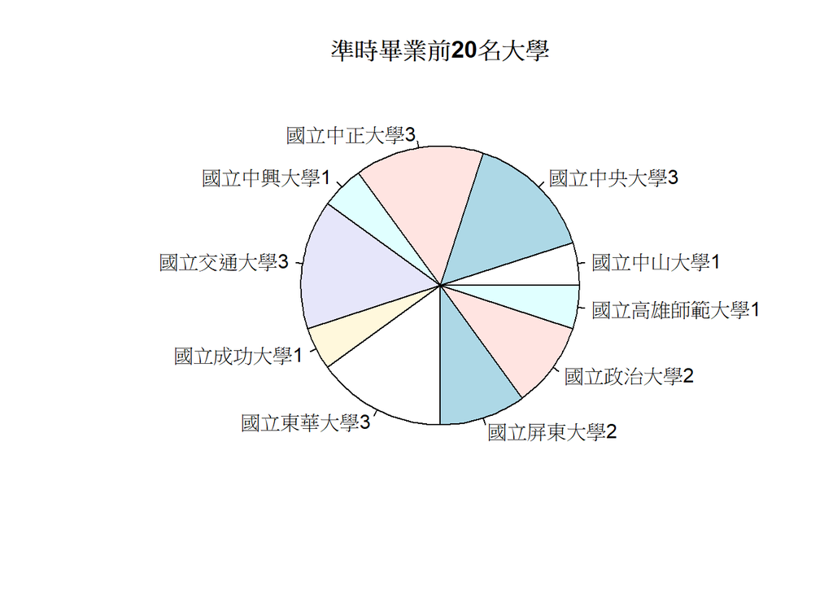

```r
#清一色國立
pie(lthsss,labels=lblslh,main="準時畢業前20名大學")
```

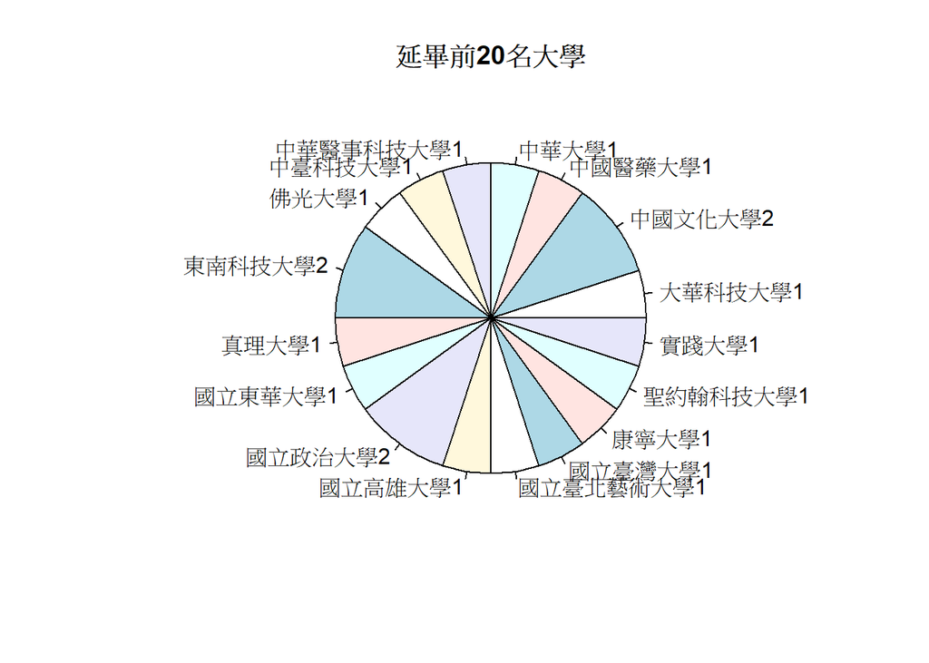

```r
lblshl <- paste(names(htlsss), htlsss, sep="")
pie(htlsss,labels=lblshl,main="延畢前20名大學")
```

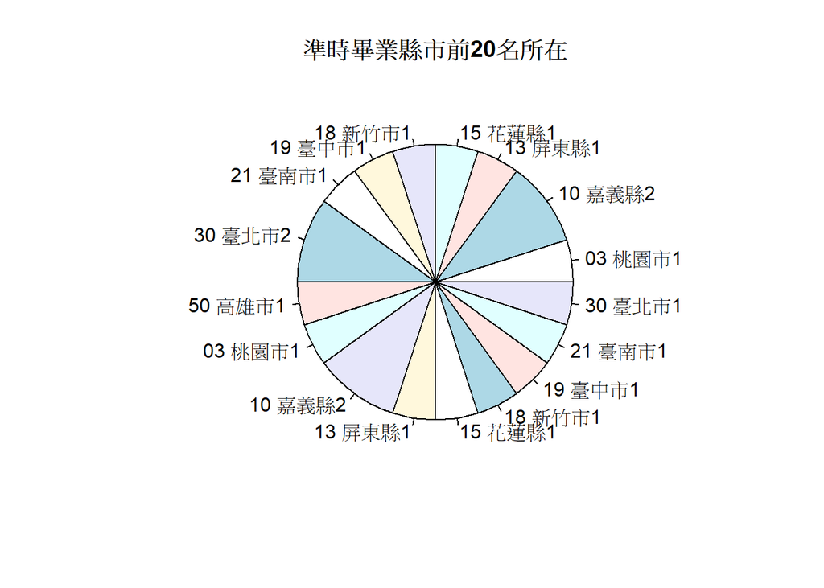

```r
sshl<-table(head(h$county[htl],20))
slhs<-table(head(h$county[lth],20))
lb1<-paste(names(sshl), htlsss, sep="")
lb2<-paste(names(slhs), htlsss, sep="")
pie(htlsss,labels=lb2,main="準時畢業縣市前20名所在")
```

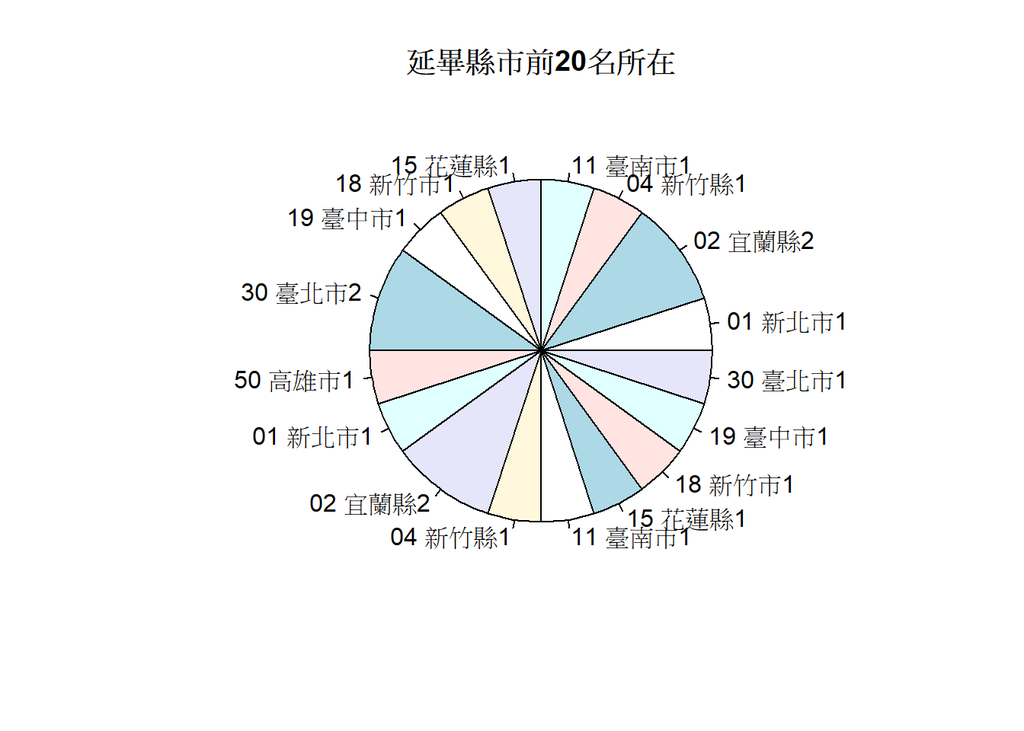

```r
pie(htlsss,labels=lb1,main="延畢縣市前20名所在")
```

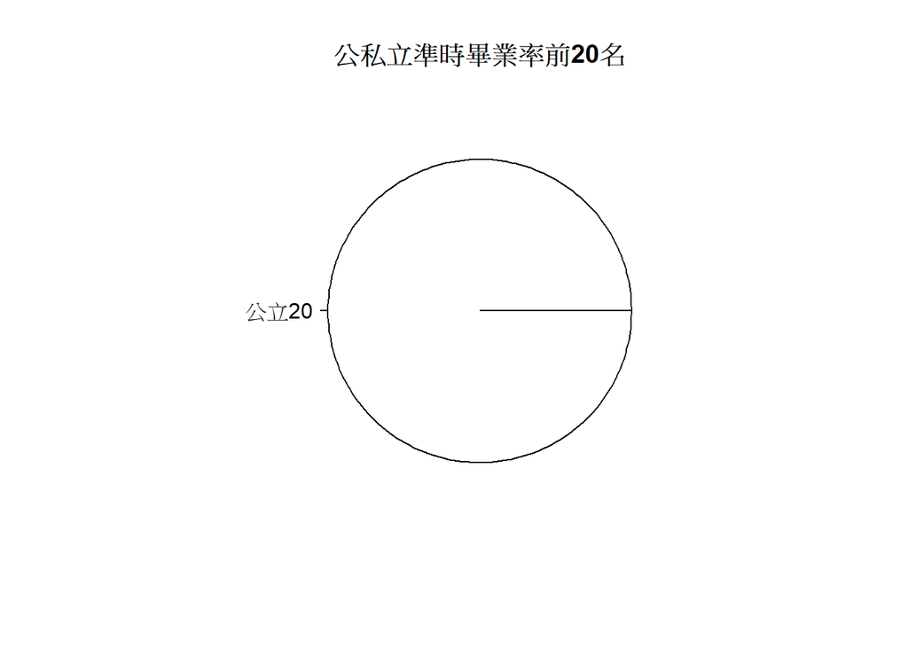

```r
ppl<-table(head(h$private_public[lth],20))
lbppl<-paste(names(ppl),ppl,sep="")
pie(ppl,label=lbppl,main="公私立準時畢業率前20名")
```

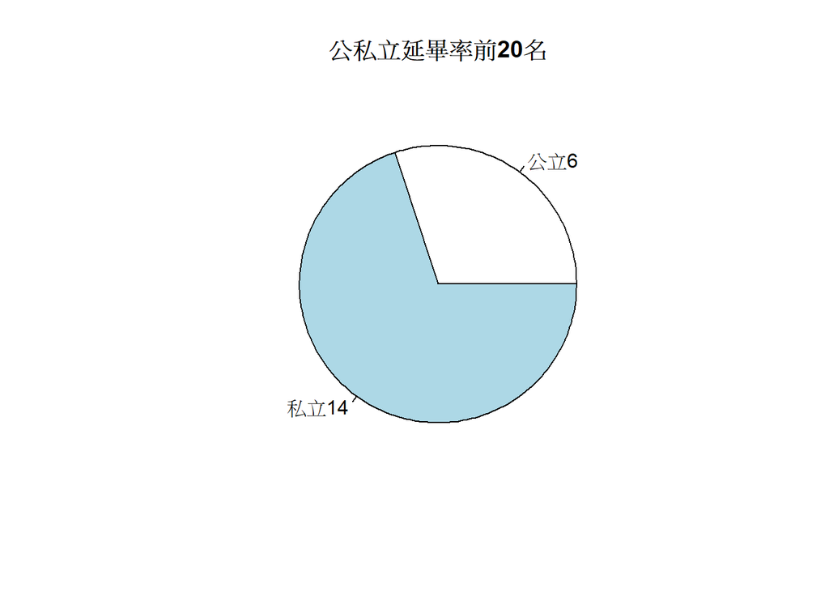

```r
del<-table(head(h$college[lth],20))
lbdel<-paste(names(del),del,sep="")
pph<-table(head(h$private_public[htl],20))
lbpph<-paste(names(pph),pph,sep="")
pie(pph,label=lbpph,main="公私立延畢率前20名")
```

```r
table(head(h$college[lth],20))
```

```
##
##      中國語文學類          化學學類      生命科學學類 生醫/醫學工程學類
##                 1                 1                 1                 1
##      企業管理學類      材料工程學類        社會學學類          政治學類
##                 1                 1                 2                 1
##      科技教育學類        英語文學類      通訊工程學類          會計學類
##                 1                 3                 1                 1
##          經濟學類      資訊工程學類          藥學學類          體育學類
##                 1                 2                 1                 1
```

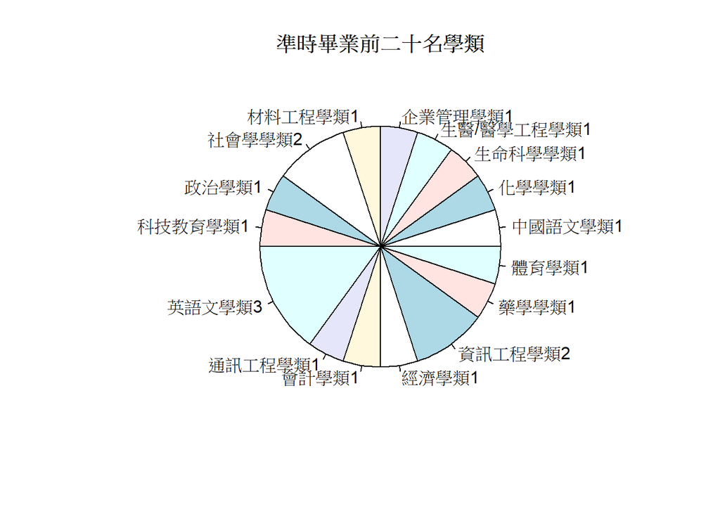

```r
pie(del,labels=lbdel,main="準時畢業前二十名學類")
```

皆使用圓餅圖，方便視覺化

```r
table(head(h$college[htl],20))
```

```
##
## 大眾傳播學類 工程科學學類 公共衛生學類 企業管理學類 休閒管理學類
##            2            1            1            1            1
## 表演藝術學類     建築學類   英語文學類 財經法律學類     新聞學類
##            3            1            3            1            1
## 資訊工程學類   歐語文學類 餐旅管理學類 醫務管理學類 觀光事業學類
##            1            1            1            1            1
```

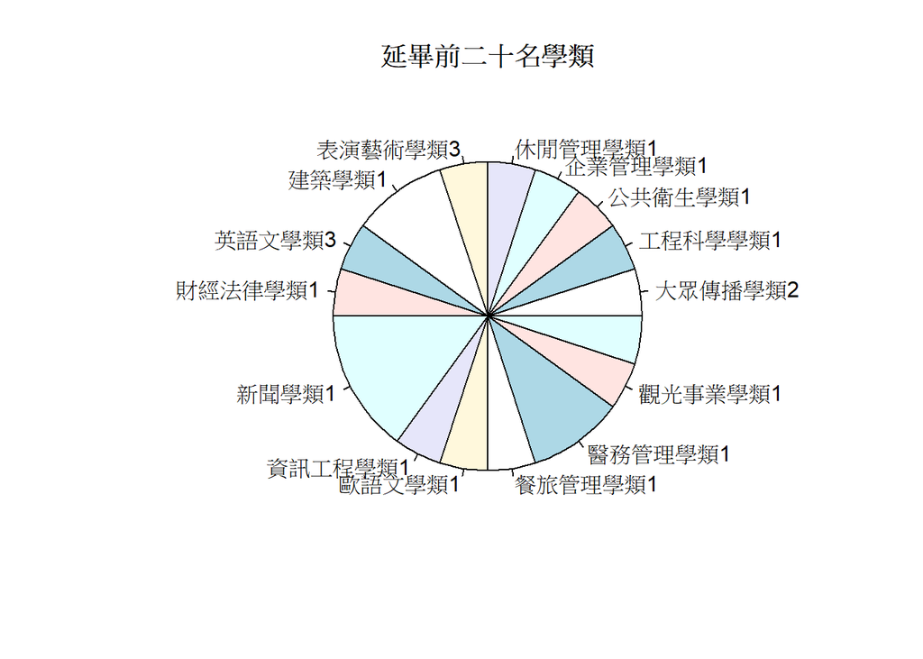

```r
deh<-table(head(h$college[htl],20))
lbdeh<-paste(names(deh),deh,sep="")
pie(del,labels=lbdeh,main="延畢前二十名學類")
```

```r
#class(s[,2])
#print(s[order(s[,2]/s[,4],decreasing=T),1])
#print(s)
#hist(deh,main='延畢前二十名學類')
```

以下是碩士與學士畢業三年後的起薪平均，也許可以做為要不要考研究所的一個參考依據(越高表示越值得念)

```r
print(s[order(s[,2],decreasing=T),1])#碩士薪水排行
```

```
##   [1] "醫學學類"               "網路學類"
##   [3] "牙醫學類"               "一般法律學類"
##   [5] "其他不能歸類之各學類"   "公共衛生學類"
##   [7] "系統設計學類"           "軟體發展學類"
##   [9] "護理學類"               "特殊教育學類"
##  [11] "教育行政學類"           "其他醫藥衛生學類"
##  [13] "核子工程學類"           "其他生命科學類"
##  [15] "運動科技學類"           "綜合教育學類"
##  [17] "身心障礙服務學類"       "社會學類"
##  [19] "專業科目教育學類"       "競技運動學類"
##  [21] "其他自然科學學類"       "其他商業及管理學類"
##  [23] "成人教育學類"           "專業法律學類"
##  [25] "其他法律學類"           "普通科目教育學類"
##  [27] "教育科技學類"           "地理學類"
##  [29] "其他教育學類"           "物理學類"
```

[output cut: 62 more lines]

```r
print(s[order(s[,4],decreasing=T),1])#學士薪水排行
```

```
##   [1] "醫學學類"               "牙醫學類"
##   [3] "其他醫藥衛生學類"       "護理學類"
##   [5] "航海學類"               "藥學學類"
##   [7] "特殊教育學類"           "測量工程學類"
##   [9] "競技運動學類"           "核子工程學類"
##  [11] "農業技術學類"           "地理學類"
##  [13] "其他不能歸類之各學類"   "復健醫學學類"
##  [15] "其他法律學類"           "其他教育學類"
##  [17] "綜合教育學類"           "政治學類"
##  [19] "一般法律學類"           "其他語文學類"
##  [21] "其他數學及統計學類"     "微生物學類"
##  [23] "農業經濟及推廣學類"     "經濟學類"
##  [25] "醫學技術及檢驗學類"     "專業科目教育學類"
##  [27] "普通科目教育學類"       "化學學類"
##  [29] "化學工程學類"           "民族學類"
```

[output cut: 62 more lines]

```r
print(paste(s[order(as.vector(s[,2])/as.vector(s[,4]),decreasing=T),1],sort(as.vector(s[,2])/as.vector(s[,4]),decreasing=T)))
```

```
##   [1] "網路學類 2.51277556799029"
##   [2] "軟體發展學類 2.42794369819949"
##   [3] "公共衛生學類 2.30735845334385"
##   [4] "運動科技學類 2.28013588414089"
##   [5] "其他生命科學類 2.15232542554617"
##   [6] "教育行政學類 2.09281978126486"
##   [7] "專業法律學類 2.08670358169202"
##   [8] "一般法律學類 2.08643151318186"
##   [9] "教育科技學類 2.06988831916836"
##  [10] "宗教學類 1.98107140247022"
##  [11] "電算機應用學類 1.9682823319187"
##  [12] "其他商業及管理學類 1.96745116035138"
##  [13] "社會學類 1.9643984063745"
##  [14] "成人教育學類 1.94494846031282"
##  [15] "其他不能歸類之各學類 1.93942247332078"
```

[output cut: 139 more lines]

## 3.圖表解析自己數據涵意推測

從圖表  
1.準時畢業前20名 全是公立大學  
而延畢前20名有百分之70來自私立大學  
結論一:知道準時畢業的比例以公立大於私立 非常明顯  
結論二:從圓餅圖對照起薪知道，延畢多待一學期以上的科目，並非與薪水成正比(也就是留得越久不代表為了薪水更多所以留下) 本來想對照縣市情況，但很分散，並不集中。  
個人認為此數據上，以大學生而言，選系不選校，再去考轉學考也許是更好的抉擇。 另外可以從碩士與學士的比值看出，醫學系學士比起念碩士的高薪，所以也許若是目標醫學，重考也許是較好的選擇。